# Pathway analysis

2025-02-27

# 1 Background

We cleaned the clinical files metadata. Now we analze the NPX data generated. For now focus on the discovery dataset

# 2 Objectives

1. Pathway analysis

# 3 Conclusion

Pathway analysis was performed on the prteins upregulated in mCRPC. We ran pathway analysis on proteins that showed progressive increase and non-linear increase seperately.

# 4 Pre-processing

## 4.1 Loading packages

```r
library(here)
library(tidyverse)
library(paletteer)
library(clusterProfiler)
library(org.Hs.eg.db)
library(msigdbr)
library(enrichplot)

library(stringr)
library(gridExtra)
```

## 4.2 Directories

```r
set.seed(1234)
wd <- list()
wd$main <- here()
wd$data <- file.path(wd$main, "data")
wd$manishData <- file.path(wd$data, "raw/data_fromManish")
wd$d2024 <- file.path(wd$data, "updated_2024")
wd$d2024_npx <- file.path(wd$d2024, "NPX_data")
wd$output <- file.path(wd$main, "output")
wd$script <- file.path(wd$main, "scripts")

wd$outData <- file.path(wd$output, "data")
wd$outCurr <- file.path(wd$output, "03_Pathway")
```

Create directories

```r
if (!file.exists(wd$outCurr)) {
  dir.create(wd$outCurr)
} else {
  print("Directory already exists")
}
```

```
## [1] "Directory already exists"
```

## 4.3 Load data

Load the processed file

```r
load(file.path(wd$outData, "01_Metadata.Rdata"))
load(file.path(wd$outData, "02_data.Rdata"))
```

Load functions

```r
source(file.path(wd$script, "functions.R"))
```

# 5 Obj 1: Pathway analysis

## 5.1 Upregulated genes

We run pathway anlaysis first on the upregulated genes in mCRPC

Lets extract the upregulated genes in mCRPC specifically

```r
genes_of_interest <- overlap_df_limma %>%
  filter(OverlapDegree %in% c(
    "Group CD")) %>% pull(Assay) %>% unique()

# If we want to look at genes that are up in both B and CD compared to A
genes_of_interest <- df_high %>%
  filter(category %in% c(
    "High_B")) %>% pull(Assay) %>% unique()
```

We need a background set for pathway enrichment. So we use all the gene ids

```r
background_genes <- df_id_pro %>% pull(Assay) %>% unique()
```

Run the pathway analysis

```r
# Convert genes of interest to Entrez IDs
foreground_entrez <- bitr(genes_of_interest,
                          fromType = "SYMBOL",
                          toType = "ENTREZID",
                          OrgDb = org.Hs.eg.db)
# Convert background genes to Entrez IDs
background_entrez <- bitr(background_genes,
                          fromType = "SYMBOL",
                          toType = "ENTREZID",
                          OrgDb = org.Hs.eg.db)
```

```r
# Remove any duplicates or NA values
foreground_entrez <- unique(na.omit(foreground_entrez))
background_entrez <- unique(na.omit(background_entrez))

# Retrieve Hallmark gene sets for Homo sapiens
msig_hallmark <- msigdbr(species = "Homo sapiens", category = "H")

# Prepare TERM2GENE as a data frame
msig_term2gene <- msig_hallmark[, c("gs_name", "entrez_gene")]


# Perform over-representation analysis with the correct TERM2GENE
enrich_results <- enricher(gene = foreground_entrez$ENTREZID,
                           TERM2GENE = msig_term2gene,
                           #universe = background_entrez$ENTREZID,
                           pAdjustMethod = "BH",
                           pvalueCutoff = 0.05,
                           qvalueCutoff = 0.2)

#barplot(enrich_results, showCategory = 10, title = "Top Enriched Hallmark Pathways")

enrich_up <- enrich_results
```

Lets generate a custom plot

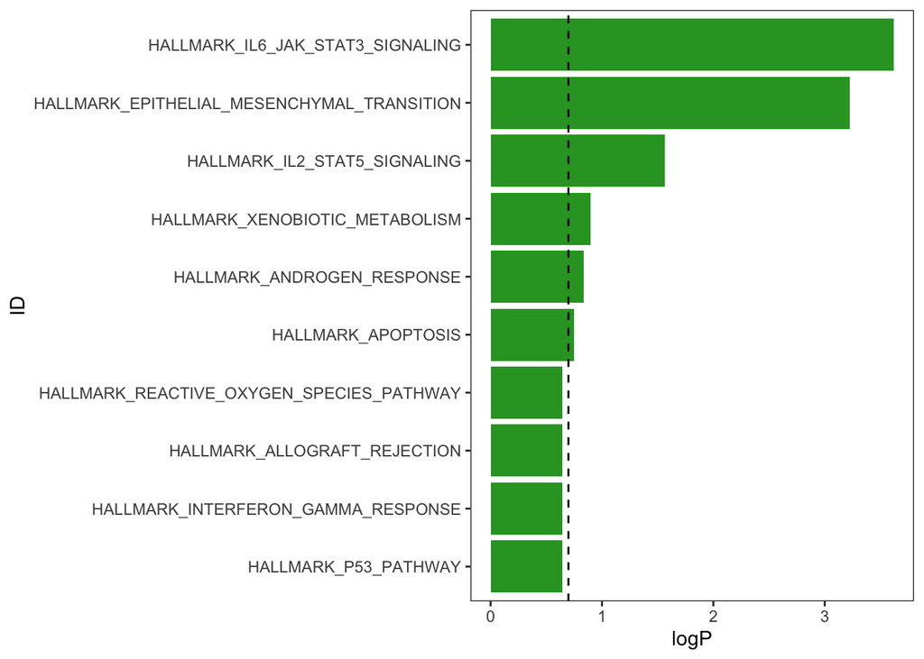

```r
# Custom plot
top_x <- enrich_up@result %>%
  #filter(p.adjust <0.2) %>%
  mutate(logP = -log10(p.adjust)) %>%
  arrange(desc(logP)) %>%
  mutate(ID = factor(ID, levels=rev(ID))) %>%
  slice_max(logP, n=10)

ggplot(top_x,
       aes(x = logP, y=ID)) +
  geom_bar(stat = "identity", fill = "#2CA02C") +  # Bars with color
  geom_vline(xintercept = -log10(0.2), linetype="dashed") +
  theme_custom +
  NULL
```

```r
#ggsave(file=file.path(wd$outCurr, "enrichedPathway.pdf"), height = 3, width = 5)
```

Repeat for the other group of genes (high in A not in B)

```r
genes_of_interest <- df_high %>%
  filter(category %in% c(
    "High_A")) %>% pull(Assay) %>% unique()

# Convert genes of interest to Entrez IDs
foreground_entrez <- bitr(genes_of_interest,
                          fromType = "SYMBOL",
                          toType = "ENTREZID",
                          OrgDb = org.Hs.eg.db)
```

```r
# Remove any duplicates or NA values
foreground_entrez <- unique(na.omit(foreground_entrez))
background_entrez <- unique(na.omit(background_entrez))

# Retrieve Hallmark gene sets for Homo sapiens
msig_hallmark <- msigdbr(species = "Homo sapiens", category = "H")

# Prepare TERM2GENE as a data frame
msig_term2gene <- msig_hallmark[, c("gs_name", "entrez_gene")]


# Perform over-representation analysis with the correct TERM2GENE
enrich_results <- enricher(gene = foreground_entrez$ENTREZID,
                           TERM2GENE = msig_term2gene,
                           #universe = background_entrez$ENTREZID,
                           pAdjustMethod = "BH",
                           pvalueCutoff = 0.05,
                           qvalueCutoff = 0.2)

enrich_up_a <- enrich_results

# Custom plot
top_x_a <- enrich_up_a@result %>%
  #filter(p.adjust <0.2) %>%
  mutate(logP = -log10(p.adjust)) %>%
  arrange(desc(logP)) %>%
  mutate(ID = factor(ID, levels=rev(ID))) %>%
  slice_max(logP, n=10)
```

Plot the two in one plot

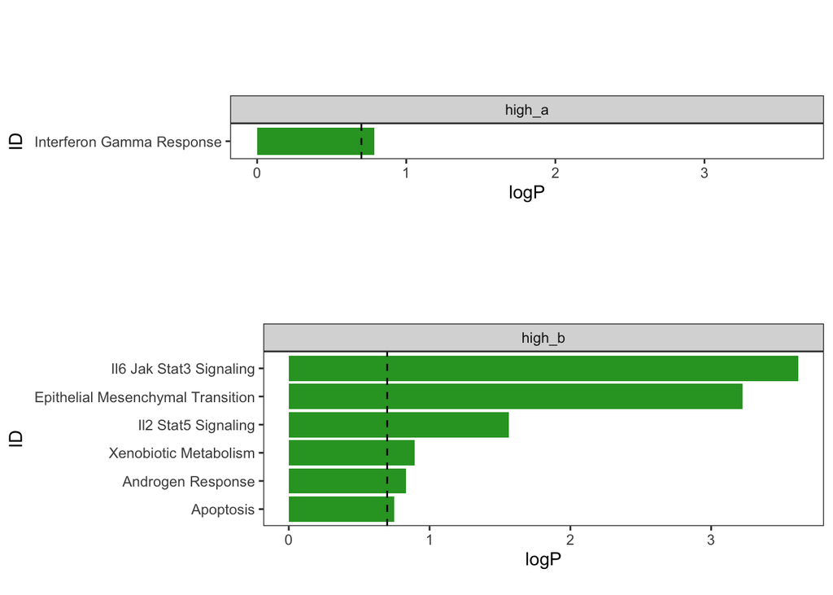

```r
t1 <- top_x_a %>% filter(p.adjust <= 0.2) %>% mutate(class = "high_a") %>% dplyr::select(logP, ID, class) %>%
  mutate(
ID = gsub("_", " ", ID),
ID = gsub("HALLMARK", "", ID),
ID = str_to_lower(ID),
ID = str_to_title(ID))
t2 <- top_x %>% filter(p.adjust <= 0.2) %>% mutate(class = "high_b") %>% dplyr::select(logP, ID, class) %>%
    mutate(
ID = gsub("_", " ", ID),
ID = gsub("HALLMARK", "", ID),
ID = str_to_lower(ID),
ID = str_to_title(ID))

# Get the full set of IDs to ensure spacing consistency
combined_IDs <- unique(c(t1$ID, t2$ID))

# Convert `ID` to a factor with all possible levels
t1$ID <- factor(t1$ID, levels = rev(combined_IDs))
t2$ID <- factor(t2$ID, levels = rev(combined_IDs))

# Get the maximum logP value across both datasets
max_logP <- max(c(t1$logP, t2$logP))

# Ensure both plots have the same x-axis scale
p1 <- ggplot(t1, aes(x = logP, y = ID)) +
  geom_bar(stat = "identity", fill = "#2CA02C") +
  geom_vline(xintercept = -log10(0.2), linetype = "dashed") +
  facet_wrap(~class) +
  xlim(0, max_logP) +  # Force both plots to have the same x-axis range
  theme_custom +
  NULL

p2 <- ggplot(t2, aes(x = logP, y = ID)) +
  geom_bar(stat = "identity", fill = "#2CA02C") +
  geom_vline(xintercept = -log10(0.2), linetype = "dashed") +
  facet_wrap(~class) +
  xlim(0, max_logP) +  # Same x-axis limit
  theme_custom +
  NULL

p1 <- p1 + coord_fixed(ratio = 0.2)  # Adjust ratio as needed
p2 <- p2 + coord_fixed(ratio = 0.2)

p_all <- grid.arrange(p1, p2, ncol = 1)
```

```r
ggsave(p_all, file=file.path(wd$outCurr, "enrichedPathway_highA_highB.pdf"), height = 6, width = 7)
```

## 5.2 Downregulated genes

Lets also try to run pathway enrichment on the downregulated genes

```r
cut_logFC_dwn <- 0.3
df_cat_cd_dwn <- limma_df %>%
  filter(Contrast %in% c("A_vs_CD", "B_vs_CD") & Adjusted_pval <= cut_fdr & log2FC <= -cut_logFC_dwn)
write.csv(df_cat_cd_dwn, "~/Desktop/tmp.csv")
```

Run pathway enrichment

```r
# Convert genes of interest to Entrez IDs
foreground_entrez <- bitr(unique(df_cat_cd_dwn$Assay),
                          fromType = "SYMBOL",
                          toType = "ENTREZID",
                          OrgDb = org.Hs.eg.db)
```

```r
# Perform over-representation analysis with the correct TERM2GENE
enrich_results <- enricher(gene = foreground_entrez$ENTREZID,
                           TERM2GENE = msig_term2gene,
                           #universe = background_entrez$ENTREZID,
                           pAdjustMethod = "BH",
                           pvalueCutoff = 0.05,
                           qvalueCutoff = 0.2)

#barplot(enrich_results, showCategory = 10, title = "Top Enriched Hallmark Pathways")

enrich_dwn <- enrich_results
```

> We do not get any valid results from the downregulation. Ignore this for now

Lets try the specific estrogen pathway

```r
estrogen_pathway <- msigdbr(species = "Homo sapiens", category = "C5", subcategory = "GO:BP") %>%
  dplyr::filter(gs_name == "GOBP_INTRACELLULAR_ESTROGEN_RECEPTOR_SIGNALING_PATHWAY")
```

```r
all_pathways <- msigdbr(species = "Homo sapiens", category = "C5", subcategory = "BP")

# Convert to TERM2GENE format (TERM column and GENE column)
msig_term2gene <- all_pathways[, c("gs_name", "entrez_gene")]

enrich_results <- enricher(
  gene = foreground_entrez$ENTREZID,
  TERM2GENE = msig_term2gene,
  pAdjustMethod = "BH",
  pvalueCutoff = 1,
  qvalueCutoff = 1
)
```

Run GSEA

```r
# Get gene set for "GOBP_RESPONSE_TO_TESTOSTERONE"
gene_set <- msigdbr(species = "Homo sapiens", category = "C5", subcategory = "BP") %>%
  dplyr::filter(gs_name == "GOBP_RESPONSE_TO_TESTOSTERONE") %>%
  dplyr::pull(gene_symbol)
```

Get the ranked genes

```r
tmp_df <- limma_df %>%
  filter(Contrast %in% c("A_vs_CD"))
ranked_genes <- tmp_df$t
names(ranked_genes) <- tmp_df$Assay
ranked_genes <- sort(ranked_genes, decreasing = TRUE)


# We need 1 gene only not duplicated
# Convert named numeric vector to data frame for processing
ranked_df <- data.frame(
  gene = names(ranked_genes),
  score = ranked_genes,
  row.names = NULL
)

# Remove duplicate gene names, keeping the highest absolute value
ranked_unique <- ranked_df %>%
  group_by(gene) %>%
  slice_max(order_by = abs(score), n = 1) %>%
  ungroup()

# Convert back to named numeric vector
geneList <- setNames(ranked_unique$score, ranked_unique$gene)

# Ensure it's sorted in decreasing order
geneList <- sort(geneList, decreasing = TRUE)
```

```r
# Create a custom gene set in a data frame
custom_gene_set <- data.frame(
  term = "GOBP_RESPONSE_TO_TESTOSTERONE",
  gene = gene_set
)

# Run GSEA with a custom gene set
gsea_custom <- GSEA(
  geneList = geneList,
  TERM2GENE = custom_gene_set,
  pvalueCutoff = 0.05,
  minGSSize = 10,
  maxGSSize = 500
)
```

```
## using 'fgsea' for GSEA analysis, please cite Korotkevich et al (2019).
```

```
## preparing geneSet collections...
```

```
## GSEA analysis...
```

```
## no term enriched under specific pvalueCutoff...
```

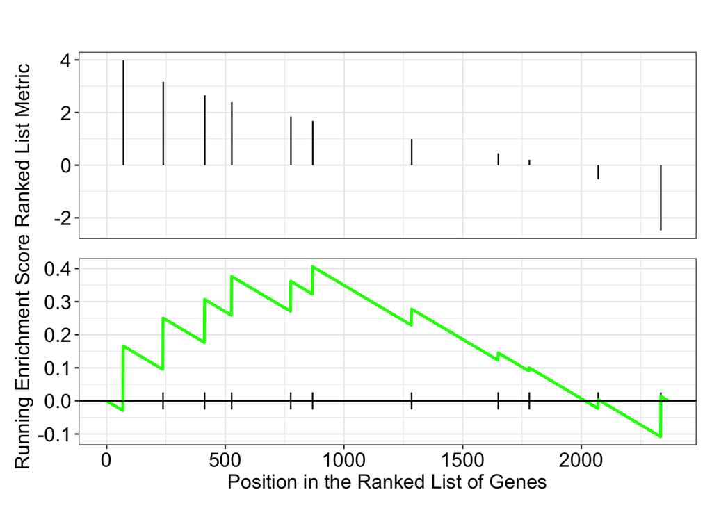

```r
# Plot the GSEA results for the specific gene set
gseaplot(gsea_custom, geneSetID = "GOBP_RESPONSE_TO_TESTOSTERONE")
```

> We could not get the GSEA or enricher to show pathways in the downregulated genes